# iAI_GAN

**Generative Adversarial Networks (GAN)**

|  | Initialized by Sung Wook Kim Revised by Prof. Seungchul Lee Industrial AI Lab http://iai.postech.ac.kr/ POSTECH |
| --- | --- |

Table of Contents

Source

- Ian Goodfellow, et al., "[Generative Adversarial Nets](https://arxiv.org/abs/1406.2661)" NIPS, 2014.
- 1시간만에 GAN (Generative Adversarial Network) 완전 정복하기
  - by 최윤제 (고려대 석사생)
  - YouTube: https://www.youtube.com/watch?v=odpjk7_tGY0
  - Slides: https://www.slideshare.net/NaverEngineering/1-gangenerative-adversarial-network
- CSC321 Lecture 19: GAN
  - By Prof. Roger Grosse at Univ. of Toronto
  - http://www.cs.toronto.edu/~rgrosse/courses/csc321_2018/
- CS231n: CNN for Visual Recognition
  - Lecture 13: Generative Models
  - By Prof. Fei-Fei Li at Stanford University
  - http://cs231n.stanford.edu/
- https://github.com/golbin/TensorFlow-Tutorials

# 1. Generative Models

## 1.1. Recap: Linear Regression

- Most people think of linear regression as points and a straight line:

[figure not shown]

- Statisticians additionally have $P_{\theta}(X \mid Z)$

[figure not shown]

- Benefits of having an error model:
  - How likely is a data point
  - Confidence bounds
  - Compare models

## 1.2. Recap: Linear Classifier

[figure not shown]

- Think about how data is generated

$$ \begin{align*} y &\sim \text{Bernoulli}(\phi)\\ x \mid y = 0 &\sim \mathcal{N}(\mu_0, \Sigma)\\ x \mid y = 1 &\sim \mathcal{N}(\mu_1, \Sigma) \end{align*} $$

[figure not shown]

## 1.3. Discriminative Model v.s. Generative Model

# 2. Density Function Estimation

- Probability

[figure not shown]

- What if $x$ is actual images in the training data? At this point, $x$ can be represented as a (for example) $64\times 64 \times 3$ dimensional vector.

[figure not shown]

- Probability density function estimation problem
- If $P_{\text{model}}(x)$ can be estimated as close to $P_{\text{data}}(x)$, then data can be generated by sampling from $P_{\text{model}}(x)$.
  - Note: Kullback–Leibler Divergence is a kind of distance measure between two distributions
- Learn determinstic transformation via a neural network
  - Start by sampling the code vector $z$ from a simple, fixed distribution such as a uniform distribution or a standard Gaussian $\mathcal{N}(0,I)$
  - Then this code vector is passed as input to a deterministic generator network $G$, which produces an output sample $x=G(z)$

[figure not shown]

- An example of a generator network which encodes a univariate distribution with two different modes

[figure not shown]

- Generative model of high dimensional space

[figure not shown]

- Generative model of images
  - learn a function which maps independent, normally-distributed $z$ values to whatever latent variables might be needed to the model, and then map those latent variables to $x$ (as images)
  - first few layers to map the normally distributed $z$ to the latent values
  - then, use later layers to map those latent values to an image

[figure not shown]

# 3. Generative Adversarial Networks (GAN)

- In generative modeling, we'd like to train a network that models a distribution, such as a distribution over images.
- GANs do not work with any explicit density function !
- Instead, take game-theoretic approach

## 3.1. Adversarial Nets Framework

- One way to judge the quality of the model is to sample from it.
- Model to produce samples which are indistinguishable from the real data, as judged by a discriminator network whose job is to tell real from fake
- The idea behind Generative Adversarial Networks (GANs): train two different networks

[figure not shown]

  - Discriminator network: try to distinguish between real and fake data

[figure not shown]

  - Generator network: try to produce realistic-looking samples to fool the discriminator network

[figure not shown]

## 3.2. Objective Function of GAN

- Think about a logistic regression classifier (or cross entropy loss $(h(x),y)$)

$$\text{loss} = -y \log h(x) - (1-y) \log (1-h(x))$$

- To train the discriminator

[figure not shown]

- To train the generator

[figure not shown]

- Non-Saturating Game when the generator is trained
  - Early in learning, when $G$ is poor, $D$ can reject samples with high confidence because they are clearly different from the training data. In this case, $\log(1-D(G(z)))$ saturates.

[figure not shown]

  - Rather than training $G$ to minimize $\log(1-D(G(z)))$ we can train $G$ to maximize $\log D(G(z))$. This objective function provides much stronger gradients early in learning.

[figure not shown]

## 3.3. Soving a Minmax Problem

Step 1: Fix $G$ and perform a gradient step to

$$\max_{D} E_{x \sim p_{\text{data}}(x)}\left[\log D(x)\right] + E_{x \sim p_{z}(z)}\left[\log (1-D(G(z)))\right]$$

Step 2: Fix $D$ and perform a gradient step to

$$\max_{G} E_{x \sim p_{z}(z)}\left[\log D(G(z))\right]$$

OR

Step 1: Fix $G$ and perform a gradient step to

$$\min_{D} E_{x \sim p_{\text{data}}(x)}\left[-\log D(x)\right] + E_{x \sim p_{z}(z)}\left[-\log (1-D(G(z)))\right]$$

Step 2: Fix $D$ and perform a gradient step to

$$\min_{G} E_{x \sim p_{z}(z)}\left[-\log D(G(z))\right]$$

## 3.4. After Training

- After training, use the generator network to generate new data

[figure not shown]

# 4. GAN with MNIST

```python
import tensorflow as tf
import matplotlib.pyplot as plt
import numpy as np

from tensorflow.examples.tutorials.mnist import input_data
mnist = input_data.read_data_sets('MNIST_data/', one_hot=True)
```

```
Extracting MNIST_data/train-images-idx3-ubyte.gz
Extracting MNIST_data/train-labels-idx1-ubyte.gz
Extracting MNIST_data/t10k-images-idx3-ubyte.gz
Extracting MNIST_data/t10k-labels-idx1-ubyte.gz
```

[figure not shown]

```python
n_D_input = 28*28
n_D_hidden = 256
n_D_output = 1

n_G_input = 100
n_G_hidden = 256
n_G_output = 28*28
```

```python
weights = {
    'G1' : tf.Variable(tf.random_normal([n_G_input, n_G_hidden], stddev=0.01)),
    'G2' : tf.Variable(tf.random_normal([n_G_hidden, n_G_output], stddev=0.01)),
    'D1' : tf.Variable(tf.random_normal([n_D_input, n_D_hidden], stddev=0.01)),
    'D2' : tf.Variable(tf.random_normal([n_D_hidden, n_D_output], stddev=0.01))
}

biases = {
    'G1' : tf.Variable(tf.zeros([n_G_hidden])),
    'G2' : tf.Variable(tf.zeros([n_G_output])),
    'D1' : tf.Variable(tf.zeros([n_D_hidden])),
    'D2' : tf.Variable(tf.zeros([n_D_output]))
}

z = tf.placeholder(tf.float32, [None, n_G_input])
x = tf.placeholder(tf.float32, [None, n_D_input])
```

```python
def generator(G_input, weights, biases):
    hidden = tf.nn.relu(tf.matmul(G_input, weights['G1']) + biases['G1'])
    output = tf.nn.sigmoid(tf.matmul(hidden, weights['G2']) + biases['G2'])
    return output
```

```python
def discriminator(D_input, weights, biases):
    hidden = tf.nn.relu(tf.matmul(D_input, weights['D1']) + biases['D1'])
    output = tf.nn.sigmoid(tf.matmul(hidden, weights['D2']) + biases['D2'])
    return output
```

```python
def make_noise(n_batch, n_G_input):
    return np.random.normal(size=(n_batch, n_G_input))
```

```python
G_output = generator(z, weights, biases)
D_fake = discriminator(G_output, weights, biases)
D_real = discriminator(x, weights, biases)
```

```python
cost_D = tf.reduce_mean(tf.log(D_real) + tf.log(1 - D_fake))
cost_G = tf.reduce_mean(tf.log(D_fake))
```

```python
D_var_list = [weights['D1'], biases['D1'], weights['D2'], biases['D2']]
G_var_list = [weights['G1'], biases['G1'], weights['G2'], biases['G2']]
```

```python
LR = 0.0002
D_train = tf.train.AdamOptimizer(LR).minimize(-cost_D, var_list = D_var_list)
G_train = tf.train.AdamOptimizer(LR).minimize(-cost_G, var_list = G_var_list)
```

```
Epoch: 0000 D_loss: -0.5226 G_loss: -2.148
```

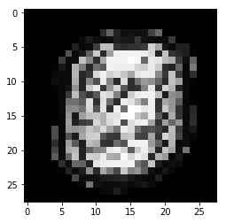

```
Epoch: 0001 D_loss: -0.1328 G_loss: -3.086
Epoch: 0002 D_loss: -0.2469 G_loss: -2.717
Epoch: 0003 D_loss: -0.4737 G_loss: -1.635
Epoch: 0004 D_loss: -0.427 G_loss: -1.667
Epoch: 0005 D_loss: -0.4855 G_loss: -2.106
Epoch: 0006 D_loss: -0.2676 G_loss: -2.638
Epoch: 0007 D_loss: -0.2406 G_loss: -2.834
Epoch: 0008 D_loss: -0.2187 G_loss: -2.985
Epoch: 0009 D_loss: -0.3143 G_loss: -2.8
Epoch: 0010 D_loss: -0.4875 G_loss: -2.232
```

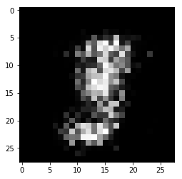

```
Epoch: 0011 D_loss: -0.5291 G_loss: -2.233
Epoch: 0012 D_loss: -0.3964 G_loss: -2.179
Epoch: 0013 D_loss: -0.3966 G_loss: -2.381
Epoch: 0014 D_loss: -0.4169 G_loss: -2.351
Epoch: 0015 D_loss: -0.4507 G_loss: -2.086
Epoch: 0016 D_loss: -0.4959 G_loss: -2.215
Epoch: 0017 D_loss: -0.3441 G_loss: -2.478
Epoch: 0018 D_loss: -0.5154 G_loss: -2.437
Epoch: 0019 D_loss: -0.4485 G_loss: -2.394
Epoch: 0020 D_loss: -0.383 G_loss: -2.454
```

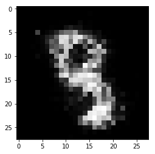

```
Epoch: 0021 D_loss: -0.3911 G_loss: -2.447
Epoch: 0022 D_loss: -0.5011 G_loss: -2.491
Epoch: 0023 D_loss: -0.4351 G_loss: -2.643
Epoch: 0024 D_loss: -0.304 G_loss: -2.694
Epoch: 0025 D_loss: -0.4621 G_loss: -2.541
Epoch: 0026 D_loss: -0.4014 G_loss: -2.459
Epoch: 0027 D_loss: -0.4228 G_loss: -2.496
Epoch: 0028 D_loss: -0.5856 G_loss: -2.048
Epoch: 0029 D_loss: -0.3515 G_loss: -2.624
Epoch: 0030 D_loss: -0.6413 G_loss: -2.595
```

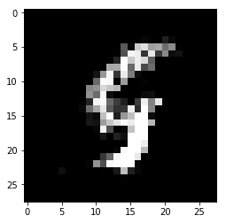

```
Epoch: 0031 D_loss: -0.4551 G_loss: -2.426
Epoch: 0032 D_loss: -0.4106 G_loss: -2.676
Epoch: 0033 D_loss: -0.4231 G_loss: -2.513
Epoch: 0034 D_loss: -0.4689 G_loss: -2.467
Epoch: 0035 D_loss: -0.6075 G_loss: -2.354
Epoch: 0036 D_loss: -0.4218 G_loss: -2.374
Epoch: 0037 D_loss: -0.4582 G_loss: -2.58
Epoch: 0038 D_loss: -0.569 G_loss: -2.547
Epoch: 0039 D_loss: -0.5068 G_loss: -2.922
Epoch: 0040 D_loss: -0.3971 G_loss: -2.54
```

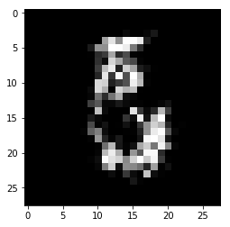

```
Epoch: 0041 D_loss: -0.5844 G_loss: -2.447
Epoch: 0042 D_loss: -0.4958 G_loss: -2.43
Epoch: 0043 D_loss: -0.5712 G_loss: -2.165
Epoch: 0044 D_loss: -0.5467 G_loss: -2.449
Epoch: 0045 D_loss: -0.6588 G_loss: -2.258
Epoch: 0046 D_loss: -0.6606 G_loss: -2.358
Epoch: 0047 D_loss: -0.6636 G_loss: -2.553
Epoch: 0048 D_loss: -0.6899 G_loss: -1.907
Epoch: 0049 D_loss: -0.5425 G_loss: -2.474
Epoch: 0050 D_loss: -0.6125 G_loss: -2.337
```

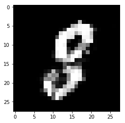

```
Epoch: 0051 D_loss: -0.6241 G_loss: -2.229
Epoch: 0052 D_loss: -0.5221 G_loss: -2.346
Epoch: 0053 D_loss: -0.7713 G_loss: -2.418
Epoch: 0054 D_loss: -0.5465 G_loss: -2.257
Epoch: 0055 D_loss: -0.7163 G_loss: -1.974
Epoch: 0056 D_loss: -0.6622 G_loss: -1.934
Epoch: 0057 D_loss: -0.5652 G_loss: -2.222
Epoch: 0058 D_loss: -0.7085 G_loss: -2.2
Epoch: 0059 D_loss: -0.7637 G_loss: -2.017
Epoch: 0060 D_loss: -0.8184 G_loss: -1.735
```

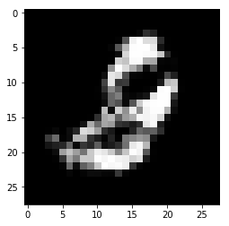

```
Epoch: 0061 D_loss: -0.5421 G_loss: -2.149
Epoch: 0062 D_loss: -0.6819 G_loss: -2.325
Epoch: 0063 D_loss: -0.6915 G_loss: -1.88
Epoch: 0064 D_loss: -0.692 G_loss: -1.908
Epoch: 0065 D_loss: -0.6722 G_loss: -2.58
Epoch: 0066 D_loss: -0.6718 G_loss: -2.089
Epoch: 0067 D_loss: -0.6866 G_loss: -1.953
Epoch: 0068 D_loss: -0.6319 G_loss: -2.287
Epoch: 0069 D_loss: -0.6779 G_loss: -1.945
Epoch: 0070 D_loss: -0.6412 G_loss: -2.197
```

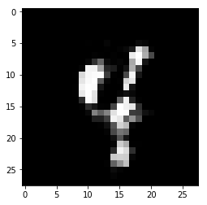

```
Epoch: 0071 D_loss: -0.6829 G_loss: -2.034
Epoch: 0072 D_loss: -0.6001 G_loss: -2.312
Epoch: 0073 D_loss: -0.6595 G_loss: -1.977
Epoch: 0074 D_loss: -0.7617 G_loss: -1.939
Epoch: 0075 D_loss: -0.7291 G_loss: -2.057
Epoch: 0076 D_loss: -0.6918 G_loss: -2.055
Epoch: 0077 D_loss: -0.813 G_loss: -1.992
Epoch: 0078 D_loss: -0.8012 G_loss: -1.739
Epoch: 0079 D_loss: -0.6122 G_loss: -2.333
Epoch: 0080 D_loss: -0.53 G_loss: -2.197
```

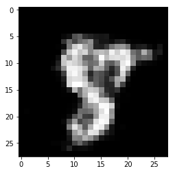

```
Epoch: 0081 D_loss: -0.6997 G_loss: -2.019
Epoch: 0082 D_loss: -0.7729 G_loss: -1.86
Epoch: 0083 D_loss: -0.545 G_loss: -2.083
Epoch: 0084 D_loss: -0.7844 G_loss: -2.083
Epoch: 0085 D_loss: -0.474 G_loss: -2.315
Epoch: 0086 D_loss: -0.6022 G_loss: -2.165
Epoch: 0087 D_loss: -0.4993 G_loss: -2.281
Epoch: 0088 D_loss: -0.6208 G_loss: -1.797
Epoch: 0089 D_loss: -0.5578 G_loss: -2.327
Epoch: 0090 D_loss: -0.6229 G_loss: -2.054
```

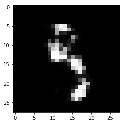

```
Epoch: 0091 D_loss: -0.5491 G_loss: -2.163
Epoch: 0092 D_loss: -0.6165 G_loss: -2.063
Epoch: 0093 D_loss: -0.639 G_loss: -2.129
Epoch: 0094 D_loss: -0.5452 G_loss: -2.047
Epoch: 0095 D_loss: -0.5109 G_loss: -2.197
Epoch: 0096 D_loss: -0.5591 G_loss: -2.435
Epoch: 0097 D_loss: -0.529 G_loss: -2.166
Epoch: 0098 D_loss: -0.5271 G_loss: -2.109
Epoch: 0099 D_loss: -0.6642 G_loss: -1.96
```

```python
n_iter = 100
n_batch = 100

sess = tf.Session()
sess.run(tf.global_variables_initializer())

D_loss_val, G_loss_val = 0, 0
total_batch = int(mnist.train.num_examples/n_batch)

for epoch in range(n_iter):
    for i in range(total_batch):
        train_x, train_y = mnist.train.next_batch(n_batch)
        noise = make_noise(n_batch, n_G_input)

        # 판별기와 생성기 신경망을 각각 학습시킨다
        _, D_loss_val = sess.run([D_train, cost_D], feed_dict={x: train_x, z: noise})
        _, G_loss_val = sess.run([G_train, cost_G], feed_dict={z: noise})

    print('Epoch:', '%04d' % epoch,
          'D_loss: {:.4}'.format(D_loss_val),
          'G_loss: {:.4}'.format(G_loss_val))

    if epoch % 10 == 0:
        noise = make_noise(n_batch, n_G_input)
        G_img = sess.run(G_output, feed_dict={z: noise})
        plt.imshow(G_img[0,:].reshape(28,28),'gray')
        plt.show()
```

```python
%%javascript
$.getScript('https://kmahelona.github.io/ipython_notebook_goodies/ipython_notebook_toc.js')
```